# stats & figs for gaze as confidence (RSPB revision 03/26)

Yoni

2026-04-10

This is a script for the RSBP revison (March 26) Script is organized according to Figures in MS.

## Fig 1& S1&2

### Try Fig1B: overall acc exp 1.

Plotting rule accuracy instead

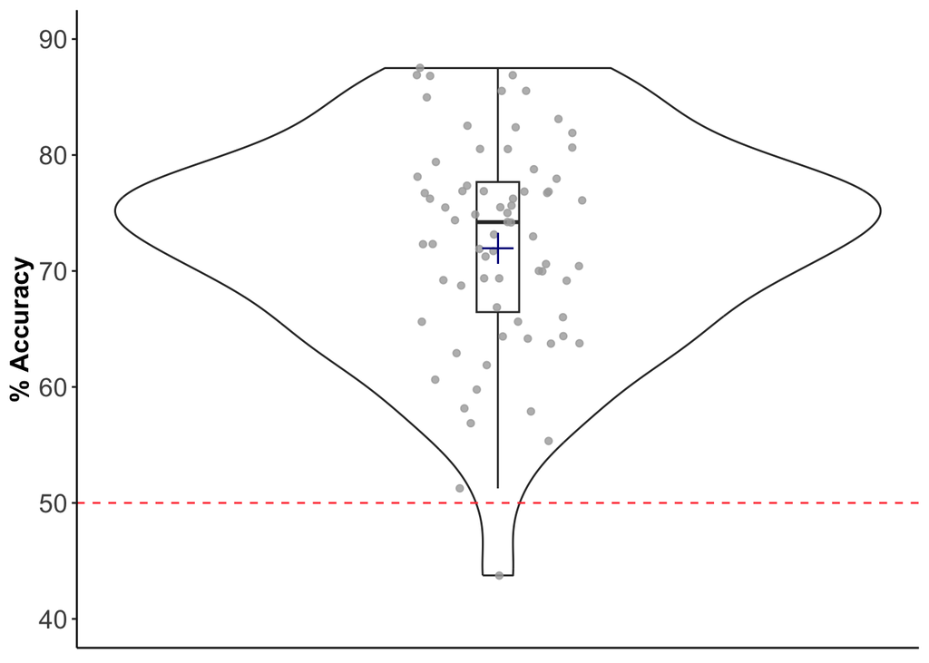

```
## # A tibble: 1 × 6
##   .y.      group1 group2     effsize     n magnitude
## * <chr>    <chr>  <chr>        <dbl> <int> <ord>
## 1 rule_acc 1      null model    2.23   111 large
```

rule acc across experiments

| mean | lo_ci | hi_ci | t | df | p.val |
| --- | --- | --- | --- | --- | --- |
| 71.518 | 69.702 | 73.334 | 23.483 | 110 | 0 |

### Fig 1C : learning curve across subjects

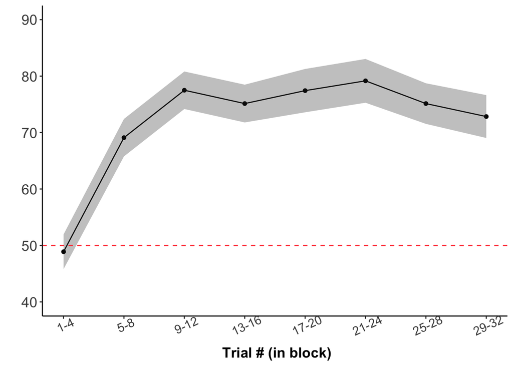

### SM Fig S1 & Table S1& S2

### S1A: overall acc

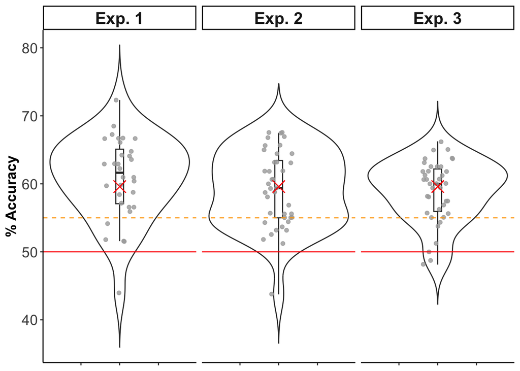

Table S1: Acc per experiment across all subjects

| exp_name | mean | lo_ci | hi_ci | t | df | p.val | ES |
| --- | --- | --- | --- | --- | --- | --- | --- |
| Exp. 1 | 60.8 | 58.7 | 63.0 | 10.2 | 31 | 0 | 10.1 |
| Exp. 2 | 59.2 | 57.4 | 61.0 | 10.4 | 39 | 0 | 10.6 |
| Exp. 3 | 58.9 | 57.5 | 60.4 | 12.3 | 38 | 0 | 13.0 |
| combined | 59.6 | 58.6 | 60.6 | 18.8 | 110 | 0 | 11.1 |

Table S1: Rule Acc per experiment across all subjects

| exp_name | mean | lo_ci | hi_ci | t | df | p.val | ES |
| --- | --- | --- | --- | --- | --- | --- | --- |
| Exp. 1 | 71.9 | 68.4 | 75.4 | 12.8 | 31 | 0 | 7.4 |
| Exp. 2 | 72.0 | 68.8 | 75.2 | 14.1 | 39 | 0 | 7.3 |
| Exp. 3 | 70.7 | 67.6 | 73.8 | 13.5 | 38 | 0 | 7.4 |
| combined | 71.5 | 69.7 | 73.3 | 23.5 | 110 | 0 | 7.4 |

### SM Fig 1B. Behav benchmarks of learning- acc on Cue valid>invalid

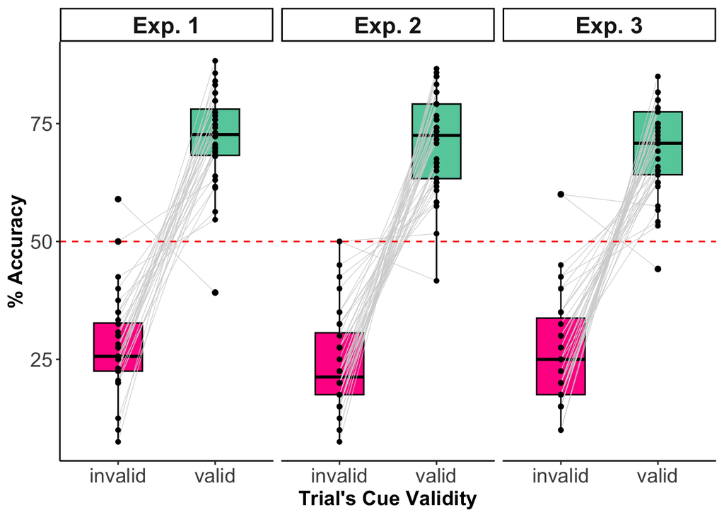

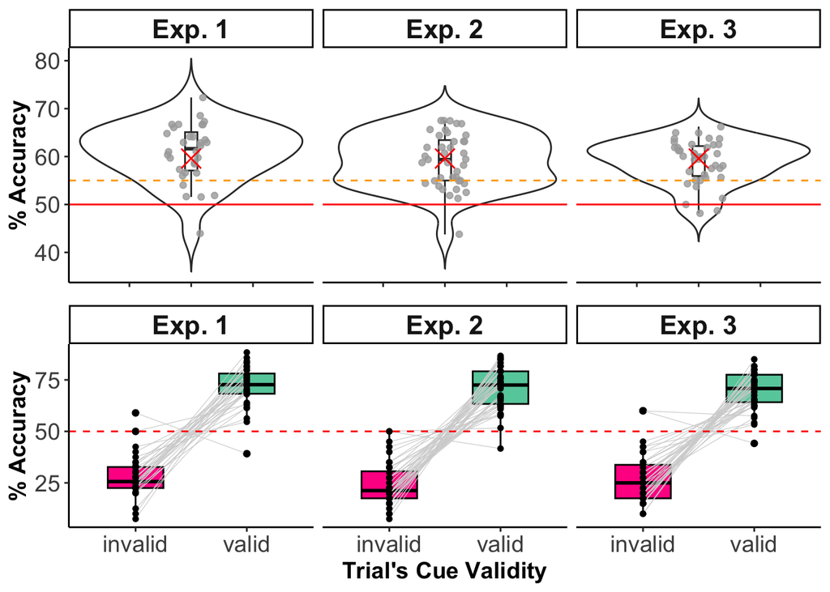

#### Table S2

Table S2 Diff Acc Cue valid vs Cue Invalid per experiment across all subjects

| exp_name | mean_diff | lo_ci | hi_ci | t | df | p.val | ES |
| --- | --- | --- | --- | --- | --- | --- | --- |
| Exp. 1 | 44.0 | 37.0 | 50.9 | 12.9 | 31 | 0 | 2.3 |
| Exp. 2 | 46.4 | 40.1 | 52.7 | 14.8 | 39 | 0 | 2.3 |
| Exp. 3 | 43.3 | 36.6 | 50.0 | 13.1 | 38 | 0 | 2.1 |
| combined | 44.6 | 40.9 | 48.3 | 23.7 | 110 | 0 | 2.3 |

### SM Figure S2

#### S2(Left): learning curve of acc- all Subjects

Note! This is graph with all of the subjects

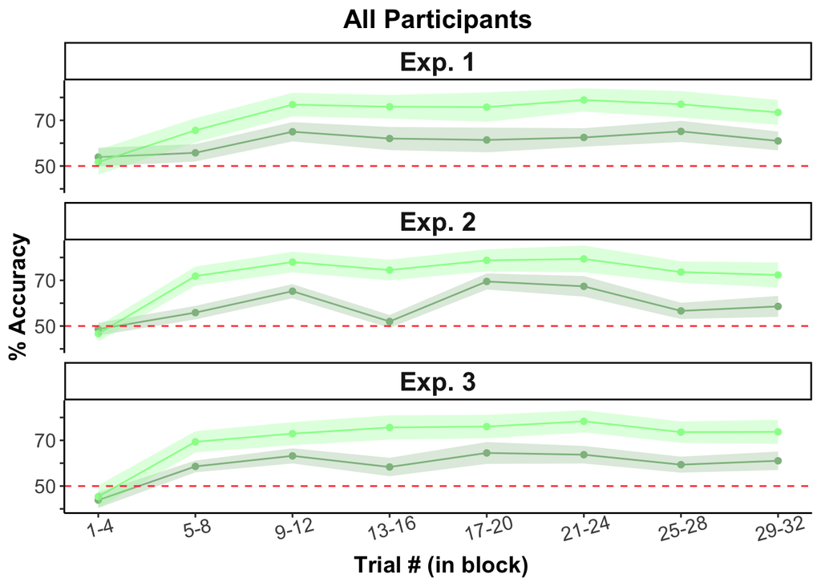

### SM Figure 2 (Right): learning curve with only pre-reg subs & trials

Rerun the same graph but only with those that are pre-registered

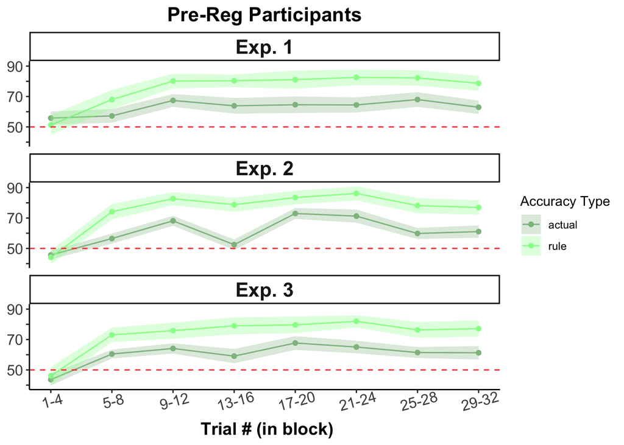

## Fig 2

### Figure 2A right: Gaze follows explicit response-ggpaired

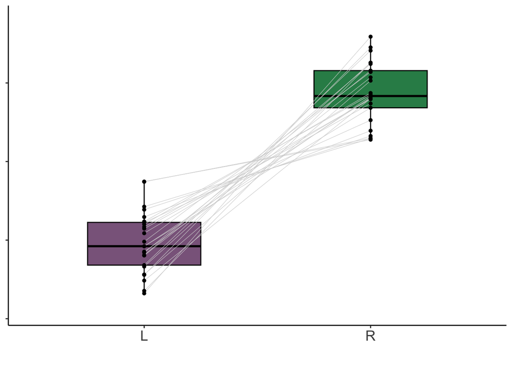

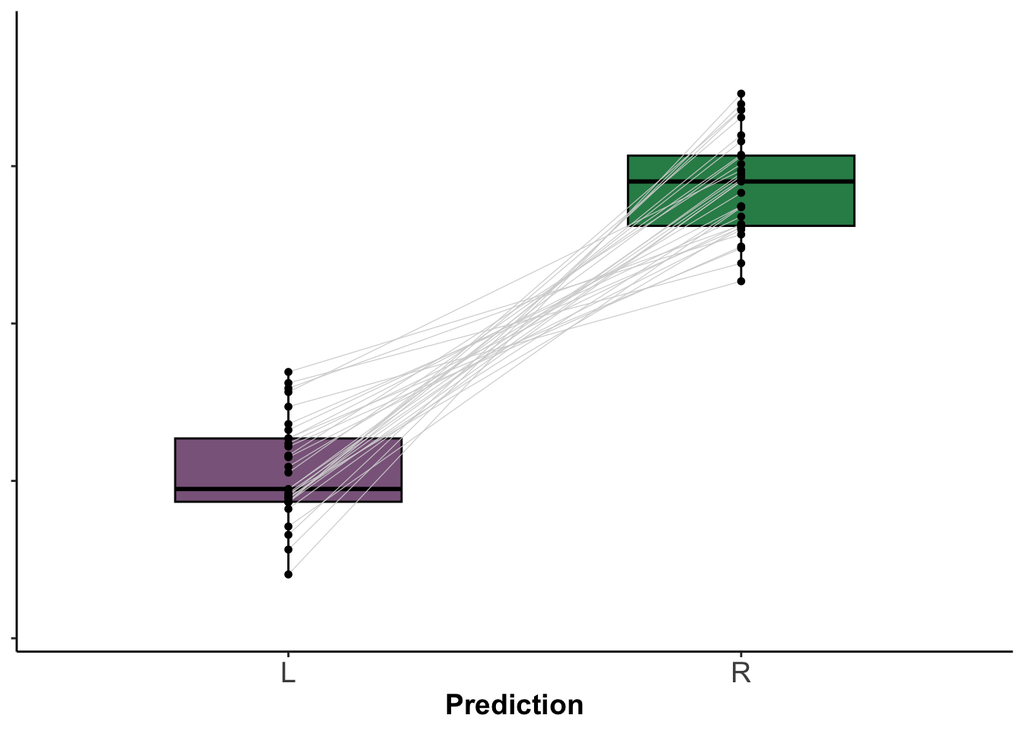

Diff gaze direction by prediction per experiment (pre-reg)

| exp_name | mean_diff | lo_ci | hi_ci | t | df | p.val | ES |
| --- | --- | --- | --- | --- | --- | --- | --- |
| Exp. 1 | 0.95 | 0.80 | 1.10 | 12.79 | 24 | 0 | 2.56 |
| Exp. 2 | 0.90 | 0.79 | 1.01 | 16.93 | 30 | 0 | 3.04 |

### Figure 2b left: Gaze follows explicit response-timecourse

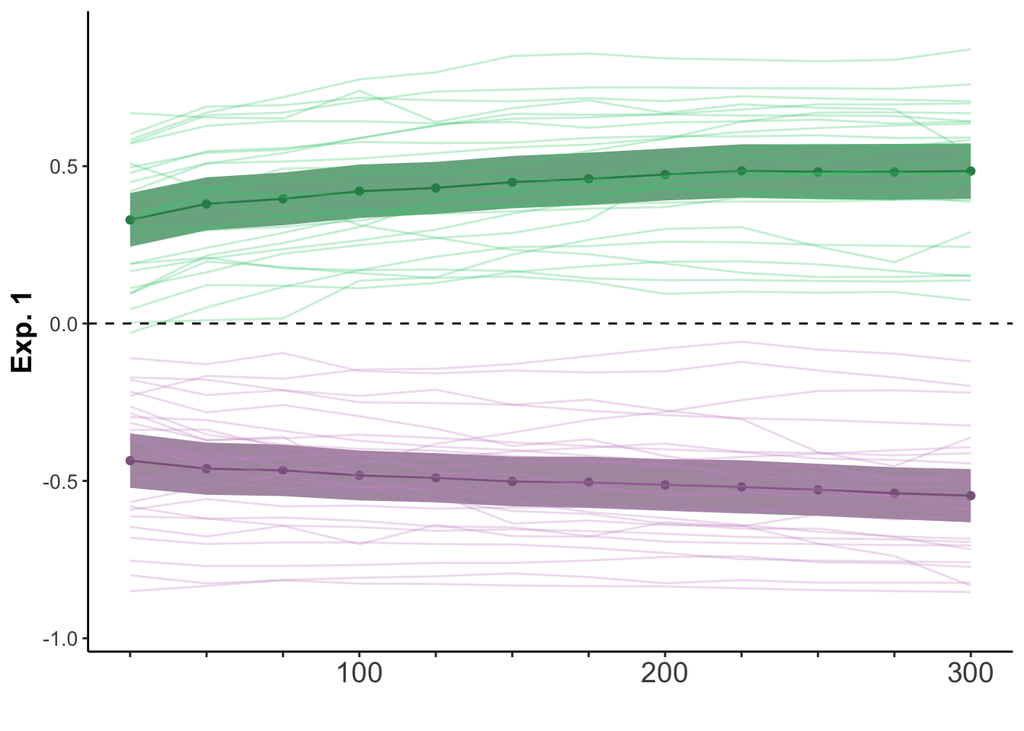

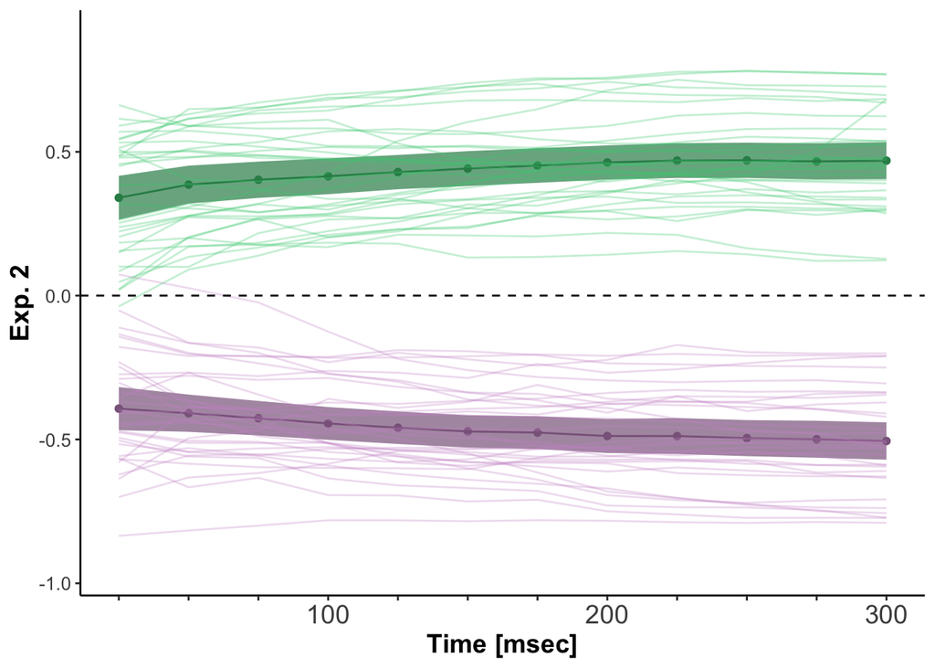

Now let’s try to combine timecourse and ggpaired using cowplot.

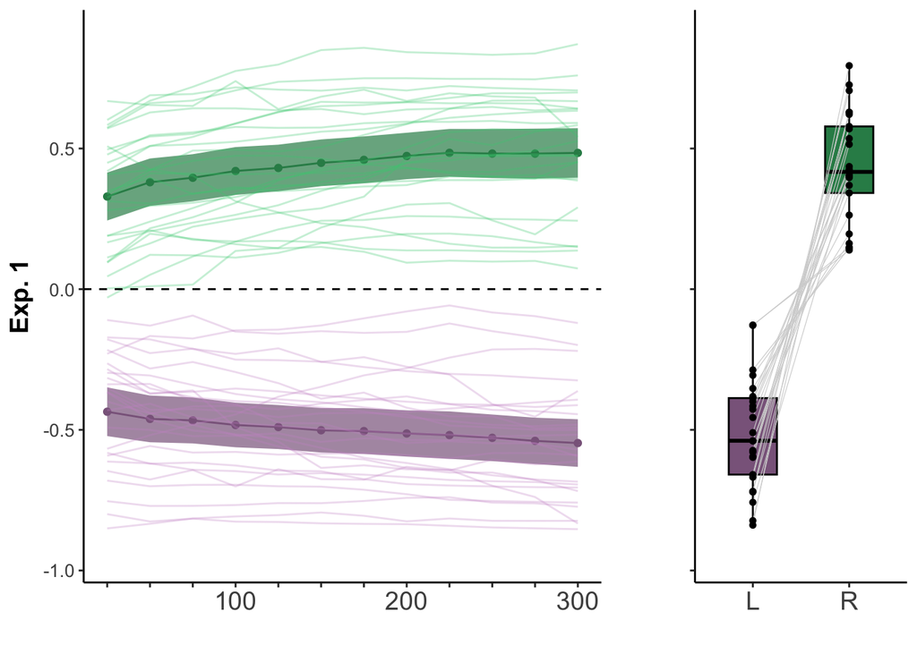

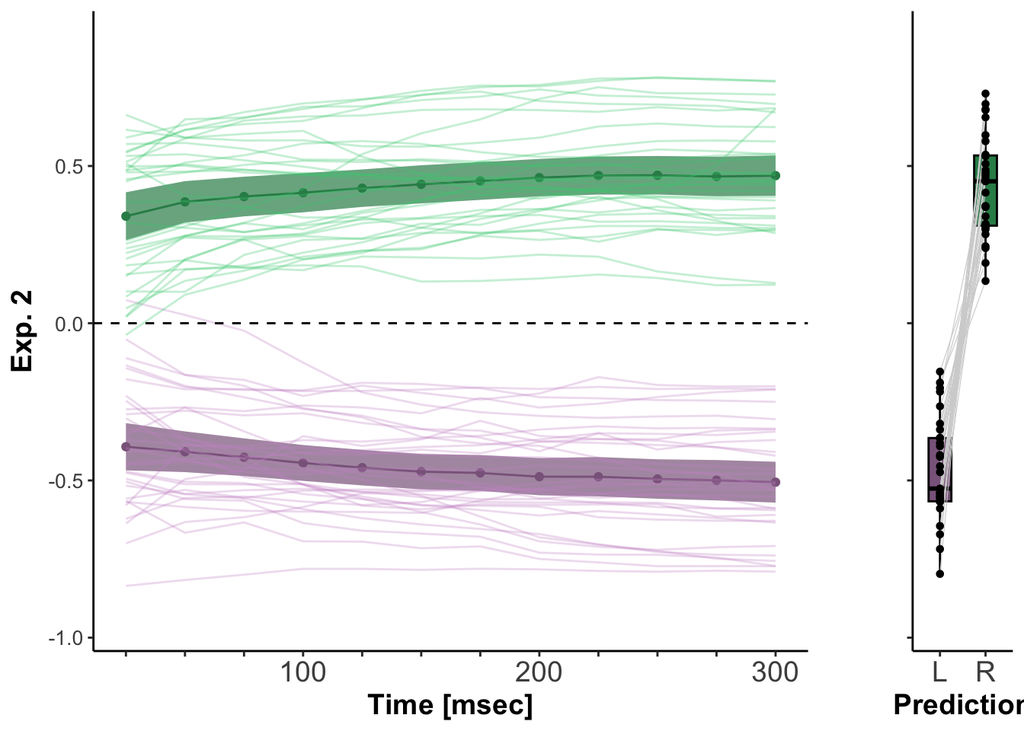

### Fig 2B Same/Diff Gaze & Explicit response

Here we are looking at Same/Diff of the eye as binary response

Convergence/divergence of Eye & Response

| exp_name | eye_resp_match | mean_porp | lo_ci | hi_ci |
| --- | --- | --- | --- | --- |
| Exp. 1 | diff | 26.03 | 21.96 | 30.09 |
| Exp. 1 | same | 73.97 | 69.91 | 78.04 |
| Exp. 2 | diff | 28.36 | 25.20 | 31.52 |
| Exp. 2 | same | 71.64 | 68.48 | 74.80 |
| Exp.1&2 | diff | 27.32 | 24.86 | 29.77 |
| Exp.1&2 | same | 72.68 | 70.23 | 75.14 |

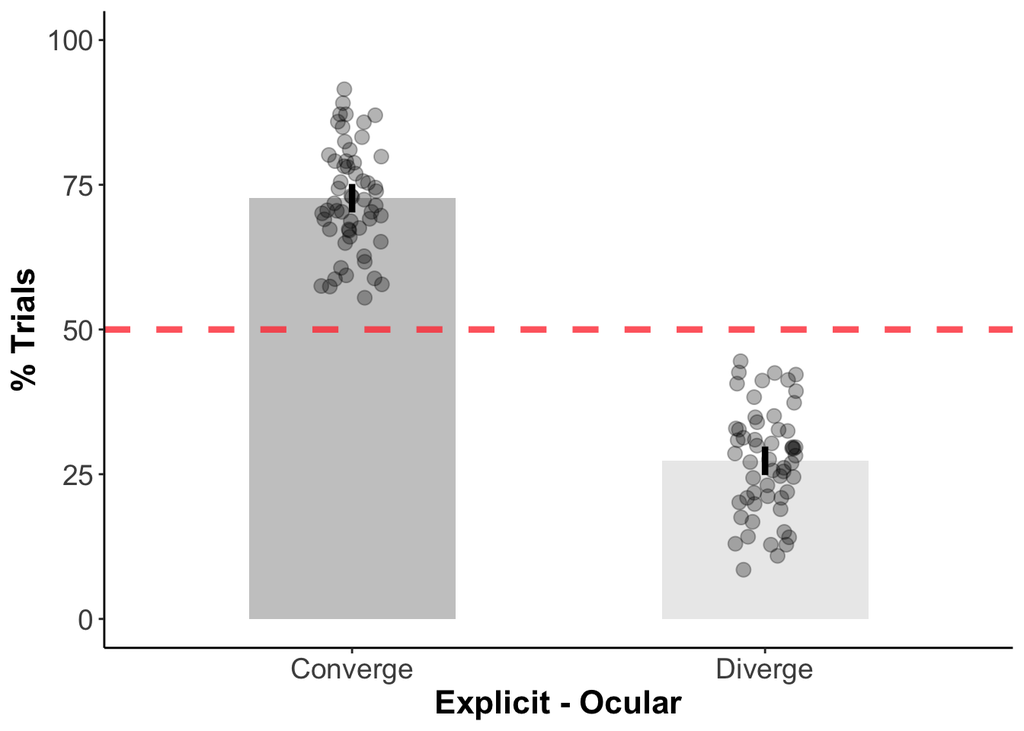

We see that around 75% explicit & eye responses are the same, but there is also considerable between subject variance

In a way this is similar to our finding that Gaze Prediction values are robustly at subject-level positive.

### Fig 2D: sRW trajectory and Gaze Prediction

First we’ll do the pre-reg analysis (individual Ss correlation) Here we are using sticky RW model. See below for use of pre-registered RW model

print stats of correlation

correlation EM and learning metric RWS

| exp_name | vars_compared | mean_corr | lo_corr | hi_corr | group_t_statistic | group_pval | ES | n_sig | total_sub |
| --- | --- | --- | --- | --- | --- | --- | --- | --- | --- |
| Exp. 1 | PC_pred_gz | 0.131 | 0.188 | 0.075 | 4.797 | 0 | 0.959 | 11 | 25 |
| Exp. 2 | PC_pred_gz | 0.106 | 0.160 | 0.051 | 3.962 | 0 | 0.712 | 11 | 31 |

Now let’s make the figures

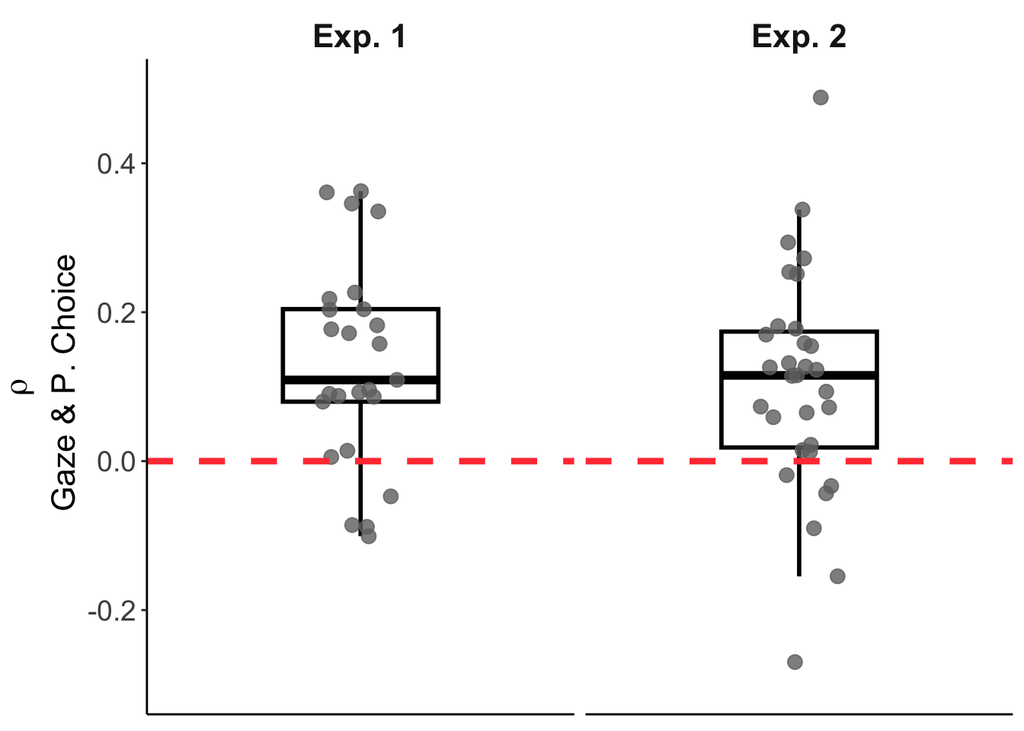

RWS corr Gaze Prediction and P. choice using mixed models

| term | npar | AIC | BIC | logLik | deviance | statistic | df | p.value |
| --- | --- | --- | --- | --- | --- | --- | --- | --- |
| pc_bygz_pred_null_mdl.res | 3 | -1109.195 | -1086.663 | 557.597 | -1115.195 | NA | NA | NA |
| pc_bygz_pred_full_mdl.res | 4 | -1251.601 | -1221.559 | 629.801 | -1259.601 | 144.406 | 1 | 0 |

### Fig 2C- Plotting trajectory of individual Ss

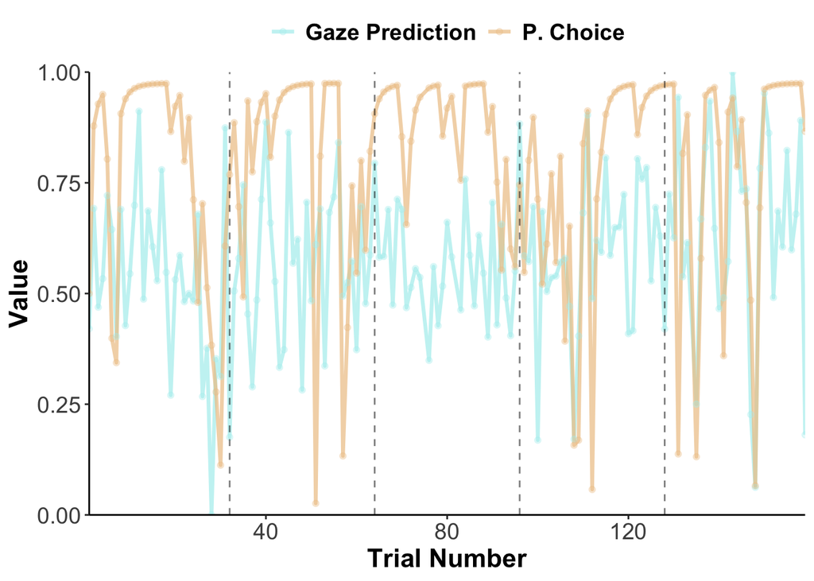

### Control analysis of Binary GP vs Continous GP

Group-Level Statistical Analysis of CGP vs GGP

|  | Variable | Mean | $t$ | $df$ | $p$ | $d$ |
| --- | --- | --- | --- | --- | --- | --- |
| mean of x | Fisher Z (Choice ~ Gaze) | 0.071 | 4.939 | 55 | < .001 | 0.66 |

Try with multiple regression gives a similar result

```
##
##  One Sample t-test
##
## data:  subject_models_r2$r2_diff
## t = 6.1857, df = 55, p-value = 8.052e-08
## alternative hypothesis: true mean is not equal to 0
## 95 percent confidence interval:
##  0.01037396 0.02031734
## sample estimates:
##  mean of x
## 0.01534565
```

```
## # A tibble: 1 × 6
##   .y.     group1 group2     effsize     n magnitude
## * <chr>   <chr>  <chr>        <dbl> <int> <ord>
## 1 r2_diff 1      null model   0.827    56 large
```

```
## # A tibble: 1 × 4
##   variable     n  mean    ci
##   <fct>    <dbl> <dbl> <dbl>
## 1 r2_diff     56 0.015 0.005
```

## SM Figures:S3, S4, S6

### Fig S3: Individual Subject Gaze by Prediction

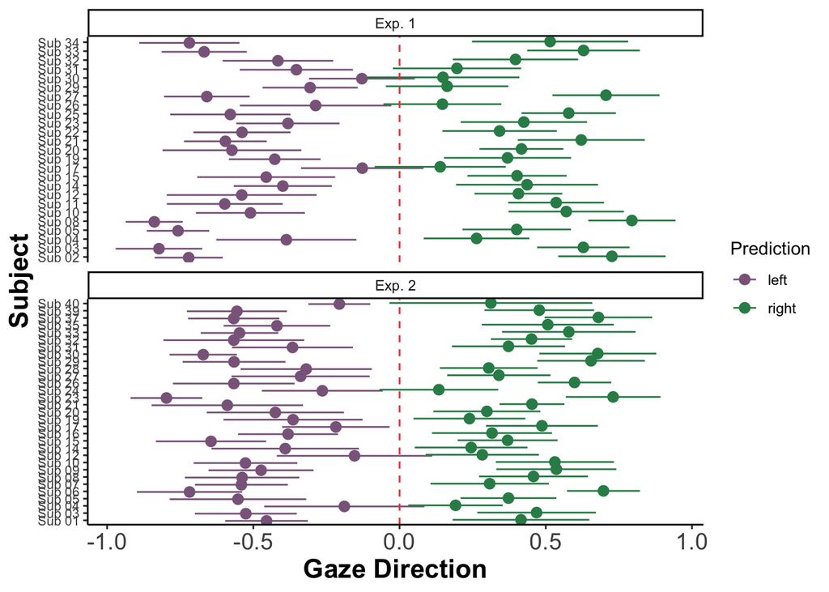

Now let’s do the stats

Gaze by Prediction, single ss signfiacne

| exp_name | n_sig | total_n |
| --- | --- | --- |
| Exp. 1 | 23 | 25 |
| Exp. 2 | 31 | 31 |
| Exp. 3 | 30 | 32 |

### SM Fig 4 convergence and dvergence per experiment

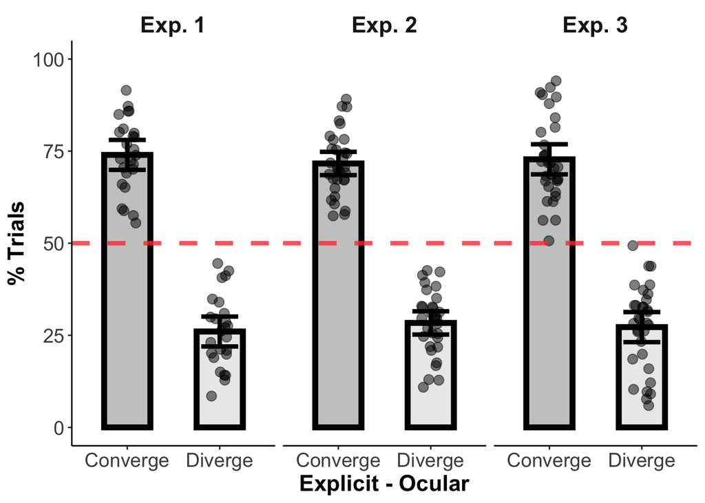

### SM Fig S6 P. Choice from RW & corr to Gaze Prediction

print stats of pre-reg analysis

correlation EM and learning metric RW (PreReged)

| exp_name | vars_compared | mean_corr | lo_corr | hi_corr | group_t_statistic | group_pval | ES | n_sig | total_sub |
| --- | --- | --- | --- | --- | --- | --- | --- | --- | --- |
| Exp. 1 | PC_pred_gz | 0.154 | 0.214 | 0.095 | 5.349 | 0.000 | 1.070 | 14 | 25 |
| Exp. 1 | da_pred_gz | -0.099 | -0.048 | -0.150 | -4.042 | 0.000 | -0.808 | 13 | 25 |
| Exp. 1 | distv5_pred_gz | 0.091 | 0.142 | 0.041 | 3.724 | 0.001 | 0.745 | 10 | 25 |
| Exp. 2 | PC_pred_gz | 0.133 | 0.187 | 0.080 | 5.064 | 0.000 | 0.910 | 15 | 31 |
| Exp. 2 | da_pred_gz | -0.107 | -0.061 | -0.153 | -4.782 | 0.000 | -0.859 | 9 | 31 |
| Exp. 2 | distv5_pred_gz | 0.086 | 0.127 | 0.045 | 4.263 | 0.000 | 0.766 | 10 | 31 |
| Exp. 3 | PC_pred_gz | 0.065 | 0.097 | 0.032 | 4.088 | 0.000 | 0.723 | 5 | 32 |
| Exp. 3 | da_pred_gz | -0.043 | -0.013 | -0.073 | -2.900 | 0.007 | -0.513 | 3 | 32 |
| Exp. 3 | distv5_pred_gz | 0.045 | 0.071 | 0.019 | 3.539 | 0.001 | 0.626 | 2 | 32 |

Checking with a mixed model

RW

| term | npar | AIC | BIC | logLik | deviance | statistic | df | p.value |
| --- | --- | --- | --- | --- | --- | --- | --- | --- |
| pc_bygz_pred_null_mdl.res_rw | 3 | -1363.147 | -1340.615 | 684.574 | -1369.147 | NA | NA | NA |
| pc_bygz_pred_full_mdl.res_rw | 4 | -1543.632 | -1513.590 | 775.816 | -1551.632 | 182.485 | 1 | 0 |

So lme gives simialr signfiacnt results using RW model.

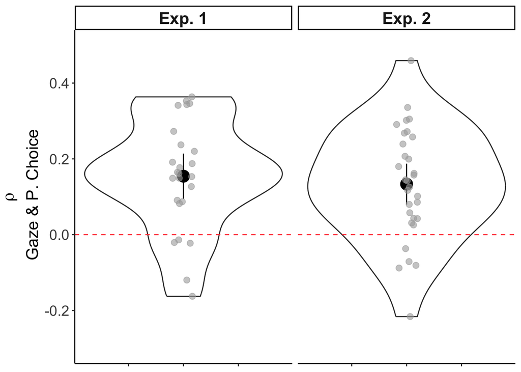

## Figure 3

Examining confidence benchmarks

### Panel A: Benchamrk 1 montonic rise in acc

Conf benchmark 1 distribution of spearman correlation

| exp_name | mean_corr | lo_corr | hi_corr | group_t_statistic | group_pval | ES |
| --- | --- | --- | --- | --- | --- | --- |
| Exp. 1 | 0.3327 | 0.5266 | 0.1388 | 3.5416 | 0.0017 | 0.7083 |
| Exp. 2 | 0.2823 | 0.4516 | 0.1130 | 3.4060 | 0.0019 | 0.6117 |
| Exp. 3 | 0.1767 | 0.3595 | -0.0062 | 1.9707 | 0.0577 | 0.3484 |

So these results aren’t super strong. But this is actually a pretty poor way of testing this hypothesis.

Let’s try now using a logistic regression approach

Conf benchmark 1 with glmer

| effect | group | term | estimate | std.error | statistic | p.value | exp_name |
| --- | --- | --- | --- | --- | --- | --- | --- |
| fixed | NA | (Intercept) | 1.04042 | 0.06487 | 16.03931 | 0 | Exp. 1 |
| fixed | NA | m_pred_gz | 0.26507 | 0.04654 | 5.69518 | 0 | Exp. 1 |
| fixed | NA | (Intercept) | 1.06429 | 0.07339 | 14.50270 | 0 | Exp. 2 |
| fixed | NA | m_pred_gz | 0.26613 | 0.04153 | 6.40856 | 0 | Exp. 2 |

So this gives a really robust result that is also statistically much more appropriate.

Visualize Panel A: benchmark 1 (Right= Exp. 1 Left Exp. 2)

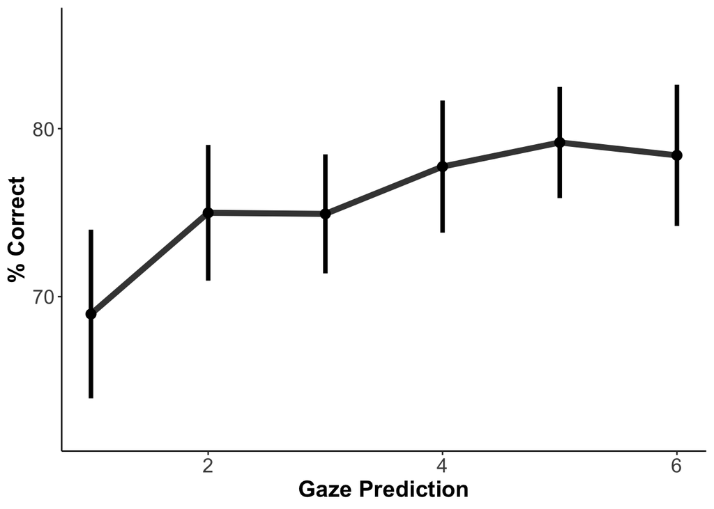

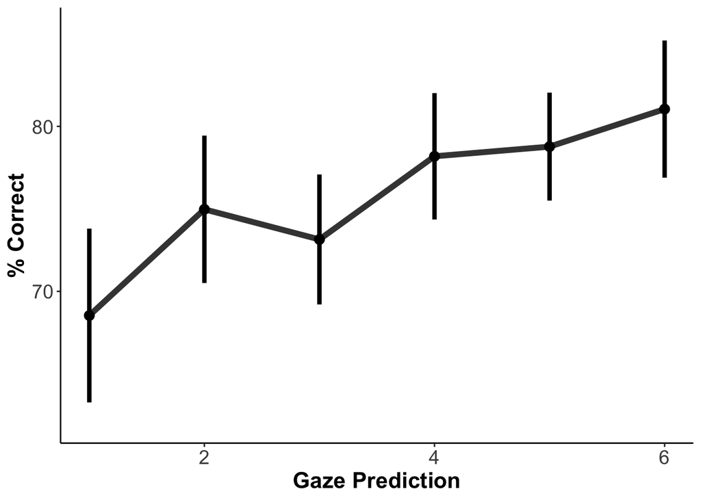

### Panel B: Benchmark 2 - folded X pattern

We are binning by expectation strength & rule accuracy

Here again we can do either with RW or RWS

#### Running with RWS

RWS lme results Benchmark 2

| term | npar | AIC | BIC | logLik | deviance | statistic | df | p.value | exp |
| --- | --- | --- | --- | --- | --- | --- | --- | --- | --- |
| bench2_full_exp1.res_rws | 6 | 9589.991 | 9627.512 | -4788.995 | 9577.991 | 9.3206 | 1 | 0.0023 | Exp. 1 |
| bench2_full_exp2.res_rws | 6 | 12097.353 | 12136.208 | -6042.677 | 12085.353 | 20.6676 | 1 | 0.0000 | Exp. 2 |

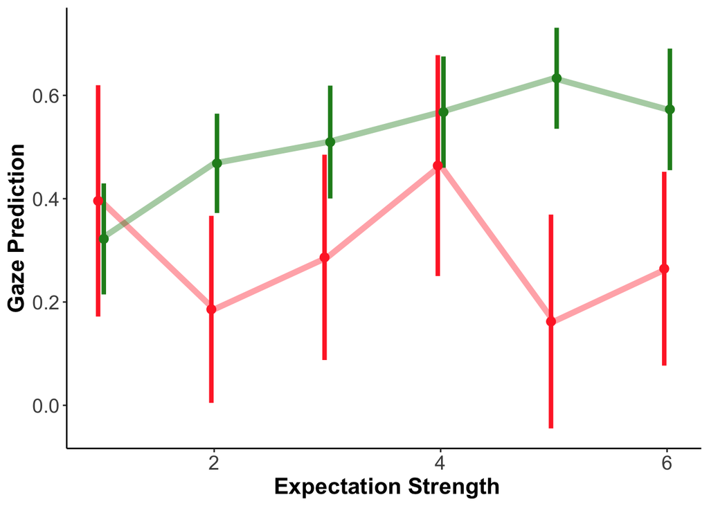

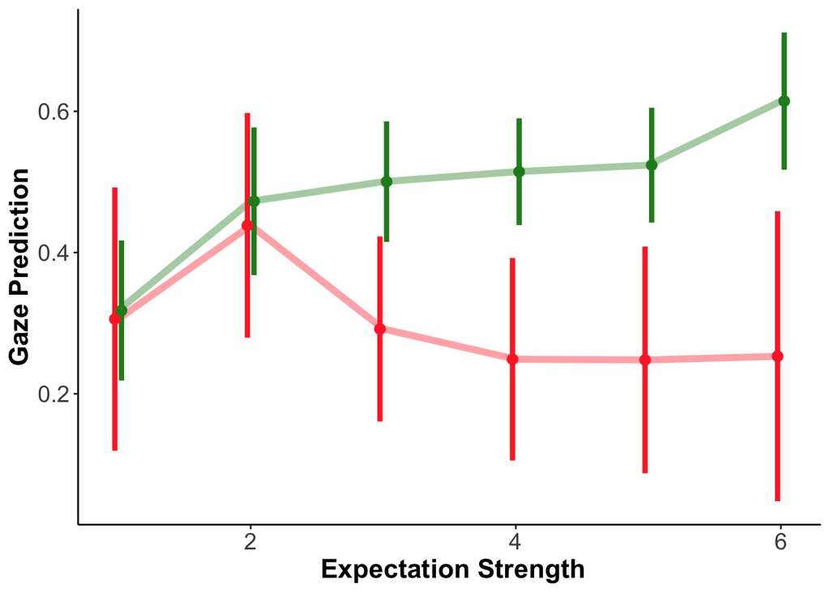

SM table B2 pairise comparison of Benchmark 2 RWS

| exp_name | dist_v_rule_acc_bin | lo_ci_0 | lo_ci_1 | hi_ci_0 | hi_ci_1 | m_gz2pred_0 | m_gz2pred_1 | p_val | t | df |
| --- | --- | --- | --- | --- | --- | --- | --- | --- | --- | --- |
| Exp. 1 | 1 | 0.6197 | 0.4296 | 0.1719 | 0.2147 | 0.3958 | 0.3222 | 0.3643 | 0.9272 | 21 |
| Exp. 1 | 2 | 0.3668 | 0.5646 | 0.0047 | 0.3723 | 0.1858 | 0.4685 | 0.0203 | -2.5109 | 21 |
| Exp. 1 | 3 | 0.4852 | 0.6189 | 0.0877 | 0.4004 | 0.2864 | 0.5096 | 0.0536 | -2.0509 | 20 |
| Exp. 1 | 4 | 0.6779 | 0.6753 | 0.2502 | 0.4599 | 0.4641 | 0.5676 | 0.5779 | -0.5657 | 20 |
| Exp. 1 | 5 | 0.3692 | 0.7310 | -0.0447 | 0.5353 | 0.1622 | 0.6332 | 0.0003 | -4.3777 | 20 |
| Exp. 1 | 6 | 0.4522 | 0.6906 | 0.0769 | 0.4552 | 0.2645 | 0.5729 | 0.0017 | -3.6473 | 19 |
| Exp. 2 | 1 | 0.4922 | 0.4171 | 0.1195 | 0.2187 | 0.3059 | 0.3179 | 0.7444 | -0.3296 | 25 |
| Exp. 2 | 2 | 0.5976 | 0.5772 | 0.2794 | 0.3680 | 0.4385 | 0.4726 | 0.7044 | -0.3838 | 25 |
| Exp. 2 | 3 | 0.4228 | 0.5857 | 0.1608 | 0.4150 | 0.2918 | 0.5004 | 0.0036 | -3.2260 | 24 |
| Exp. 2 | 4 | 0.3923 | 0.5900 | 0.1055 | 0.4389 | 0.2489 | 0.5144 | 0.0024 | -3.3856 | 24 |
| Exp. 2 | 5 | 0.4085 | 0.6051 | 0.0874 | 0.4425 | 0.2480 | 0.5238 | 0.0012 | -3.6888 | 23 |
| Exp. 2 | 6 | 0.4586 | 0.7117 | 0.0479 | 0.5172 | 0.2532 | 0.6144 | 0.0041 | -3.1869 | 23 |
| Exp. 3 | 1 | 0.5340 | 0.5032 | 0.2199 | 0.2778 | 0.3770 | 0.3905 | 0.8817 | -0.1501 | 30 |
| Exp. 3 | 2 | 0.3810 | 0.5500 | 0.1437 | 0.3749 | 0.2623 | 0.4624 | 0.0077 | -2.8643 | 29 |
| Exp. 3 | 3 | 0.5129 | 0.5076 | 0.2304 | 0.3198 | 0.3716 | 0.4137 | 0.7883 | -0.2711 | 28 |
| Exp. 3 | 4 | 0.4813 | 0.5710 | 0.1807 | 0.4076 | 0.3310 | 0.4893 | 0.0614 | -1.9490 | 28 |
| Exp. 3 | 5 | 0.5113 | 0.6654 | 0.1951 | 0.5070 | 0.3532 | 0.5862 | 0.0018 | -3.4842 | 26 |
| Exp. 3 | 6 | 0.7201 | 0.6172 | 0.3931 | 0.3989 | 0.5566 | 0.5081 | 0.4961 | 0.6911 | 24 |

### Fig 3C: Benchmark 3 - steeper curve for high Gaze prediction trials

#### RWS

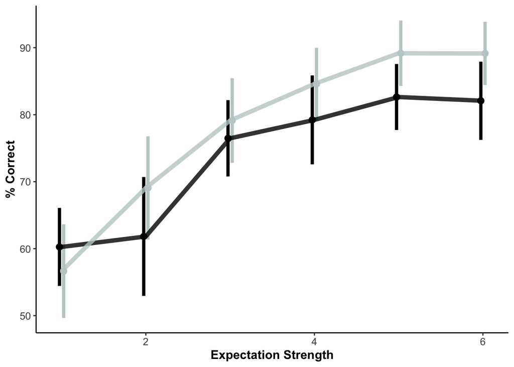

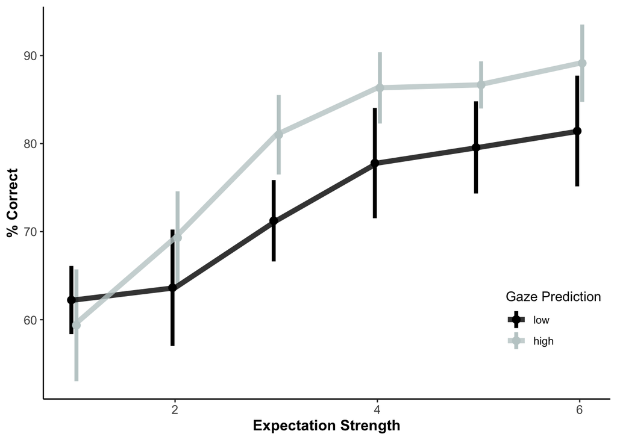

Benchmark 3 RWS (glmer)

| effect | group | term | estimate | std.error | statistic | p.value | exp_name |
| --- | --- | --- | --- | --- | --- | --- | --- |
| fixed | NA | (Intercept) | 0.4268423 | 0.2594215 | 1.6453625 | 0.0998951 | Exp. 1 |
| fixed | NA | pred_gz_bin | -0.2304368 | 0.1659172 | -1.3888657 | 0.1648736 | Exp. 1 |
| fixed | NA | dist_v_bin | 0.1027834 | 0.0735716 | 1.3970534 | 0.1623975 | Exp. 1 |
| fixed | NA | pred_gz_bin:dist_v_bin | 0.1531692 | 0.0484909 | 3.1587214 | 0.0015846 | Exp. 1 |
| fixed | NA | (Intercept) | 0.3611247 | 0.2375613 | 1.5201329 | 0.1284776 | Exp. 2 |
| fixed | NA | pred_gz_bin | -0.1079814 | 0.1492352 | -0.7235651 | 0.4693328 | Exp. 2 |
| fixed | NA | dist_v_bin | 0.0677893 | 0.0652881 | 1.0383099 | 0.2991258 | Exp. 2 |
| fixed | NA | pred_gz_bin:dist_v_bin | 0.1554912 | 0.0431693 | 3.6018969 | 0.0003159 | Exp. 2 |

### Additional anaylses on Folded X pattern

#### Examine if there is signficant downward slope in the FXP

Following Rev. 2’s request Here we have an issue of sufficient trials We are running with all subjects and also with Ss >= 30 error trials

FXP’s negative slope m_pred_gz~expl.RWS.dist_v_5 (all subs)

| term | npar | AIC | BIC | logLik | deviance | statistic | df | p.value |
| --- | --- | --- | --- | --- | --- | --- | --- | --- |
| m_null2 | 3 | 5451.801 | 5468.749 | -2722.901 | 5445.801 | NA | NA | NA |
| bench2_negative_trend_full_frmla.RWS | 4 | 5449.713 | 5472.310 | -2720.857 | 5441.713 | 4.088 | 1 | 0.043 |

Fixed effects for the negative trend model (all subs)

| effect | term | estimate | std.error | statistic |
| --- | --- | --- | --- | --- |
| fixed | (Intercept) | 0.371 | 0.044 | 8.427 |
| fixed | expl.RWS.dist_v_5 | -0.305 | 0.151 | -2.023 |

FXP’s negative slope m_pred_gz~expl.RWS.dist_v_5 (min 30 trials)

| term | npar | AIC | BIC | logLik | deviance | statistic | df | p.value |
| --- | --- | --- | --- | --- | --- | --- | --- | --- |
| m_null2_m | 3 | 4775.920 | 4792.443 | -2384.960 | 4769.920 | NA | NA | NA |
| bench2_negative_trend_full_frmla.RWS_m | 4 | 4771.747 | 4793.778 | -2381.874 | 4763.747 | 6.173 | 1 | 0.013 |

Fixed effects for the negative trend model (min 30 trials)

| effect | term | estimate | std.error | statistic |
| --- | --- | --- | --- | --- |
| fixed | (Intercept) | 0.382 | 0.049 | 7.753 |
| fixed | expl.RWS.dist_v_5 | -0.404 | 0.162 | -2.487 |

### run on FXP’s positive slope

FXP’s positive slope m_pred_gz~expl.RWS.dist_v_5 (all subs)

| term | npar | AIC | BIC | logLik | deviance | statistic | df | p.value |
| --- | --- | --- | --- | --- | --- | --- | --- | --- |
| m_null2 | 3 | 16301.24 | 16321.59 | -8147.618 | 16295.24 | NA | NA | NA |
| bench2_positive_trend_full_frmla.RWS | 4 | 16232.59 | 16259.73 | -8112.296 | 16224.59 | 70.645 | 1 | 0 |

Fixed effects for the positive trend model (all subs)

| effect | term | estimate | std.error | statistic |
| --- | --- | --- | --- | --- |
| fixed | (Intercept) | 0.341 | 0.028 | 12.097 |
| fixed | expl.RWS.dist_v_5 | 0.649 | 0.077 | 8.431 |

FXP’s positive slope m_pred_gz~expl.RWS.dist_v_5 (min 30 trials)

| term | npar | AIC | BIC | logLik | deviance | statistic | df | p.value |
| --- | --- | --- | --- | --- | --- | --- | --- | --- |
| m_null2_m | 3 | 16301.24 | 16321.59 | -8147.618 | 16295.24 | NA | NA | NA |
| bench2_positive_trend_full_frmla.RWS_m | 4 | 16232.59 | 16259.73 | -8112.296 | 16224.59 | 70.645 | 1 | 0 |

Fixed effects for the positive trend model (min 30 trials)

| effect | term | estimate | std.error | statistic |
| --- | --- | --- | --- | --- |
| fixed | (Intercept) | 0.341 | 0.028 | 12.097 |
| fixed | expl.RWS.dist_v_5 | 0.649 | 0.077 | 8.431 |

#### Rev. 2 request to test FXP as a function of trial position within block

Here we are looking at the FXP as a function of early/middle/ late trials within block

so we define as early/mid/late 1-12, 13-22, 23-32 Let’s use fixed bins of expectatin strength

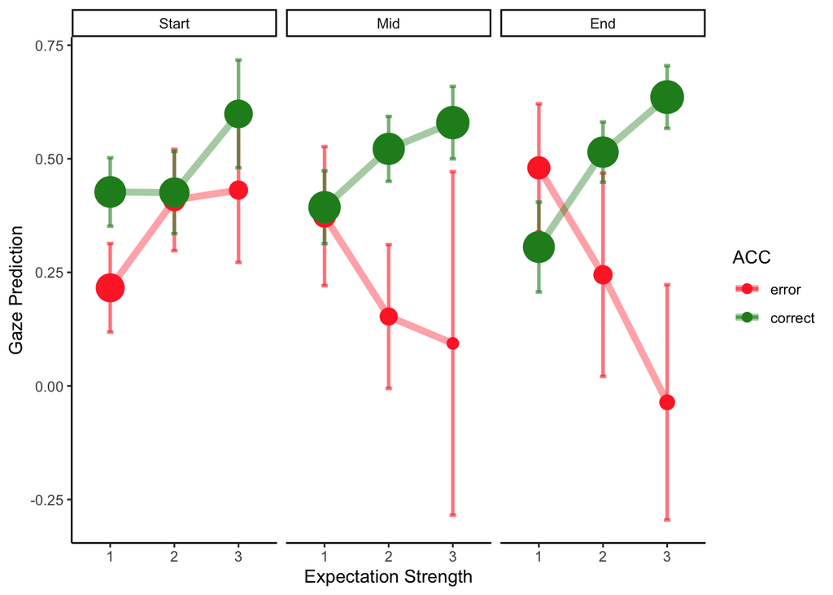

Let’s test this statisticaally

#### Now Running stats on the downward slope of FXP by trial position in block

RMANOVA of FXP by trial position in blk

| term | Effect | DFn | DFd | F | p | p<.05 | ges | Start_mean | Start_lo_ci | Start_hi_ci | Mid_mean | Mid_lo_ci | Mid_hi_ci | End_mean | End_lo_ci | End_hi_ci |
| --- | --- | --- | --- | --- | --- | --- | --- | --- | --- | --- | --- | --- | --- | --- | --- | --- |
| interaction | trial_pos_blk | 2 | 76 | 8.960 | 0.000 | * | 0.128 | -0.062 | -0.180 | 0.056 | 0.307 | 0.136 | 0.478 | 0.398 | 0.214 | 0.582 |
| positive_slope | trial_pos_blk | 2 | 96 | 2.696 | 0.073 |  | 0.029 | 0.071 | 0.001 | 0.141 | 0.116 | 0.059 | 0.173 | 0.166 | 0.100 | 0.232 |
| negative_slope | trial_pos_blk | 2 | 76 | 7.164 | 0.001 | * | 0.109 | 0.134 | 0.047 | 0.221 | -0.191 | -0.348 | -0.034 | -0.231 | -0.411 | -0.051 |

### Table S5 & S6 PWC of benchmarks

Table S5

SM table B2 pairise comparison of Benchmark 2 RWS

| exp_name | dist_v_rule_acc_bin | lo_ci_0 | lo_ci_1 | hi_ci_0 | hi_ci_1 | m_gz2pred_0 | m_gz2pred_1 | p_val | t | df |
| --- | --- | --- | --- | --- | --- | --- | --- | --- | --- | --- |
| Exp. 1 | 1 | 0.6197 | 0.4296 | 0.1719 | 0.2147 | 0.3958 | 0.3222 | 0.3643 | 0.9272 | 21 |
| Exp. 1 | 2 | 0.3668 | 0.5646 | 0.0047 | 0.3723 | 0.1858 | 0.4685 | 0.0203 | -2.5109 | 21 |
| Exp. 1 | 3 | 0.4852 | 0.6189 | 0.0877 | 0.4004 | 0.2864 | 0.5096 | 0.0536 | -2.0509 | 20 |
| Exp. 1 | 4 | 0.6779 | 0.6753 | 0.2502 | 0.4599 | 0.4641 | 0.5676 | 0.5779 | -0.5657 | 20 |
| Exp. 1 | 5 | 0.3692 | 0.7310 | -0.0447 | 0.5353 | 0.1622 | 0.6332 | 0.0003 | -4.3777 | 20 |
| Exp. 1 | 6 | 0.4522 | 0.6906 | 0.0769 | 0.4552 | 0.2645 | 0.5729 | 0.0017 | -3.6473 | 19 |
| Exp. 2 | 1 | 0.4922 | 0.4171 | 0.1195 | 0.2187 | 0.3059 | 0.3179 | 0.7444 | -0.3296 | 25 |
| Exp. 2 | 2 | 0.5976 | 0.5772 | 0.2794 | 0.3680 | 0.4385 | 0.4726 | 0.7044 | -0.3838 | 25 |
| Exp. 2 | 3 | 0.4228 | 0.5857 | 0.1608 | 0.4150 | 0.2918 | 0.5004 | 0.0036 | -3.2260 | 24 |
| Exp. 2 | 4 | 0.3923 | 0.5900 | 0.1055 | 0.4389 | 0.2489 | 0.5144 | 0.0024 | -3.3856 | 24 |
| Exp. 2 | 5 | 0.4085 | 0.6051 | 0.0874 | 0.4425 | 0.2480 | 0.5238 | 0.0012 | -3.6888 | 23 |
| Exp. 2 | 6 | 0.4586 | 0.7117 | 0.0479 | 0.5172 | 0.2532 | 0.6144 | 0.0041 | -3.1869 | 23 |
| Exp. 3 | 1 | 0.5340 | 0.5032 | 0.2199 | 0.2778 | 0.3770 | 0.3905 | 0.8817 | -0.1501 | 30 |
| Exp. 3 | 2 | 0.3810 | 0.5500 | 0.1437 | 0.3749 | 0.2623 | 0.4624 | 0.0077 | -2.8643 | 29 |
| Exp. 3 | 3 | 0.5129 | 0.5076 | 0.2304 | 0.3198 | 0.3716 | 0.4137 | 0.7883 | -0.2711 | 28 |
| Exp. 3 | 4 | 0.4813 | 0.5710 | 0.1807 | 0.4076 | 0.3310 | 0.4893 | 0.0614 | -1.9490 | 28 |
| Exp. 3 | 5 | 0.5113 | 0.6654 | 0.1951 | 0.5070 | 0.3532 | 0.5862 | 0.0018 | -3.4842 | 26 |
| Exp. 3 | 6 | 0.7201 | 0.6172 | 0.3931 | 0.3989 | 0.5566 | 0.5081 | 0.4961 | 0.6911 | 24 |

### Fig. S7 Confidence Hallmarks using RW RW

#### Fig S7 Right

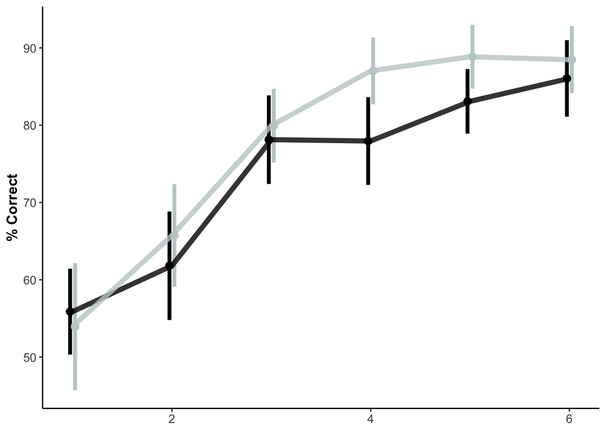

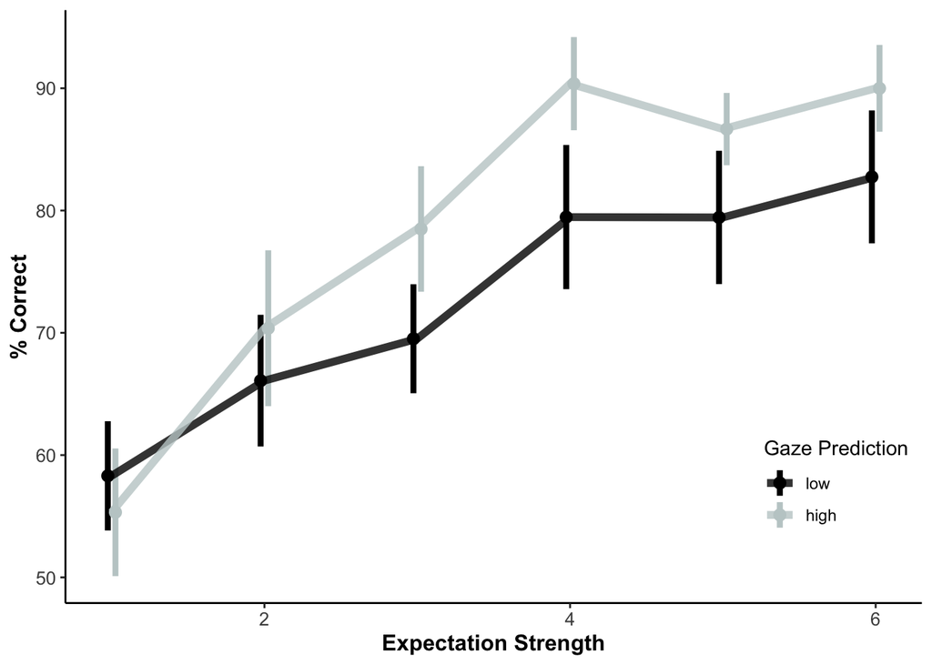

Benchmark 3 (glmer)

| effect | group | term | estimate | std.error | statistic | p.value | exp_name |
| --- | --- | --- | --- | --- | --- | --- | --- |
| fixed | NA | (Intercept) | 0.0553951 | 0.2609975 | 0.2122439 | 0.8319167 | Exp. 1 |
| fixed | NA | pred_gz_bin | -0.0926035 | 0.1660699 | -0.5576175 | 0.5771056 | Exp. 1 |
| fixed | NA | dist_v_bin | 0.2221092 | 0.0757746 | 2.9311819 | 0.0033768 | Exp. 1 |
| fixed | NA | pred_gz_bin:dist_v_bin | 0.1109852 | 0.0495981 | 2.2376908 | 0.0252412 | Exp. 1 |
| fixed | NA | (Intercept) | 0.3254890 | 0.2381790 | 1.3665733 | 0.1717591 | Exp. 2 |
| fixed | NA | pred_gz_bin | -0.1724367 | 0.1493580 | -1.1545190 | 0.2482875 | Exp. 2 |
| fixed | NA | dist_v_bin | 0.0763765 | 0.0663759 | 1.1506672 | 0.2498692 | Exp. 2 |
| fixed | NA | pred_gz_bin:dist_v_bin | 0.1793884 | 0.0440190 | 4.0752545 | 0.0000460 | Exp. 2 |

## Fig 4

First let’s examine the relation between explicit cnfidence and P. Choice

### Correlation of Confidence and RWS trial-by-trial trajectories

correlation Confidence Ratings and sRW trajectories

| vars_compared | mean_corr | hi_CI | lo_CI | group_t_statistic | group_pval | ES | n_sig | total_sub |
| --- | --- | --- | --- | --- | --- | --- | --- | --- |
| conf_PC | 0.384 | 0.438 | 0.330 | 14.468 | 0 | 2.558 | 30 | 32 |
| conf_prev_delta | -0.266 | -0.195 | -0.337 | -7.612 | 0 | -1.346 | 22 | 32 |

So there is a super robust correlation between P. Choice and confidence ratings 30/32 Ss are significant!

### Figure 4A

Correlation of confidence & Gaze

Experiment 3 correlation Confidence Ratings and EM

| vars_compared | mean_corr | lo_corr | hi_corr | group_t_statistic | group_pval | ES | n_sig | total_sub |
| --- | --- | --- | --- | --- | --- | --- | --- | --- |
| conf_gz2pred | 0.0756 | 0.038 | 0.1132 | 4.1023 | 3e-04 | 0.7252 | 8 | 32 |

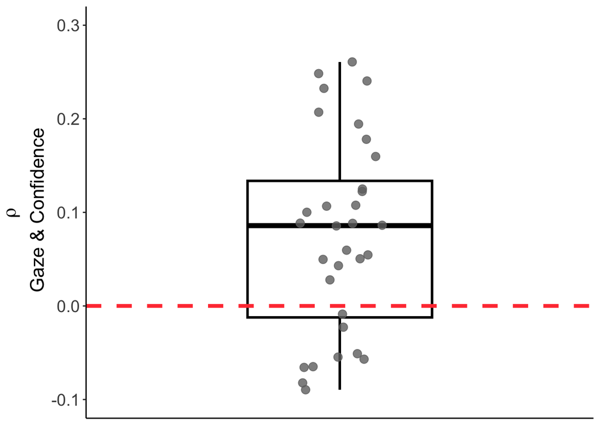

### Control analysis of Relation between Confidence and Gaze Prediction beyond p. choice

Running a mixed model examining relation between Gaze, confidence & other factors

So confidence & gaze are correlated but we also know that there are both correlated with a bunch of other factors (most notably P. Choice, accuracy). So using mixed models lets try to tease apart these factors

MM results of gaze by confidence & P. Choice

| term | npar | AIC | BIC | logLik | deviance | statistic | df | p.value |
| --- | --- | --- | --- | --- | --- | --- | --- | --- |
| gz_conf_mdl2_full.res | 5 | 13083.54 | 13115.99 | -6536.771 | 13073.54 | 11.6167 | 1 | 7e-04 |

getting effect size of gaze

Variance explained (R2) by adding Gaze Prediction

| Model | Marginal_R2 |
| --- | --- |
| Reduced | 0.1463 |
| Full | 0.1489 |
| Difference | 0.0026 |

```
## Cohen's f2 for the addition of gaze prediction is: 0.003
```

#### Trying a group summary approach.

We fit for each subject individually while controlling for additional factors and then do a group ttest

Gaze Prediction correlated to confidence beyond p choice

| predictor | statistic | df | p | effsize | variable | n | mean | ci |
| --- | --- | --- | --- | --- | --- | --- | --- | --- |
| beta_explRWS | 13.444 | 31 | 0.000 | 2.377 | val | 32 | 1.669 | 0.253 |
| beta_m_pred_gz | 2.932 | 31 | 0.006 | 0.518 | val | 32 | 0.069 | 0.048 |

Looking at additional factors: m_pred_gz~z_conf_rating+expl.RWS.p_choice+resp_rule_acc+expl.RWS.prev_delta+(1|sub_name)

MM results of gaze by confidence & other variables

| term | npar | AIC | BIC | logLik | deviance | statistic | df | p.value |
| --- | --- | --- | --- | --- | --- | --- | --- | --- |
| gz_conf_mdl2_full.res | 7 | 11892.77 | 11938.18 | -5939.387 | 11878.77 | 9.5152 | 1 | 0.002 |

#### looking at the inverse relation with Gaze Prediction as DV

Gaze Prediction correlated to confidence beyond other factors

| predictor | statistic | df | p | effsize | variable | n | mean | ci |
| --- | --- | --- | --- | --- | --- | --- | --- | --- |
| beta_explRWS | 2.084 | 31 | 0.046 | 0.368 | val | 32 | 0.150 | 0.146 |
| beta_prev_delta | -1.066 | 31 | 0.294 | -0.189 | val | 32 | -0.944 | 1.806 |
| beta_resp_rule_acc | 1.235 | 31 | 0.226 | 0.218 | val | 32 | 0.046 | 0.076 |
| beta_z_conf_rating | 2.295 | 31 | 0.029 | 0.406 | val | 32 | 0.039 | 0.035 |

### Fig 4 B

Comparing metacognition of eye vs. explicit ratings confidence.

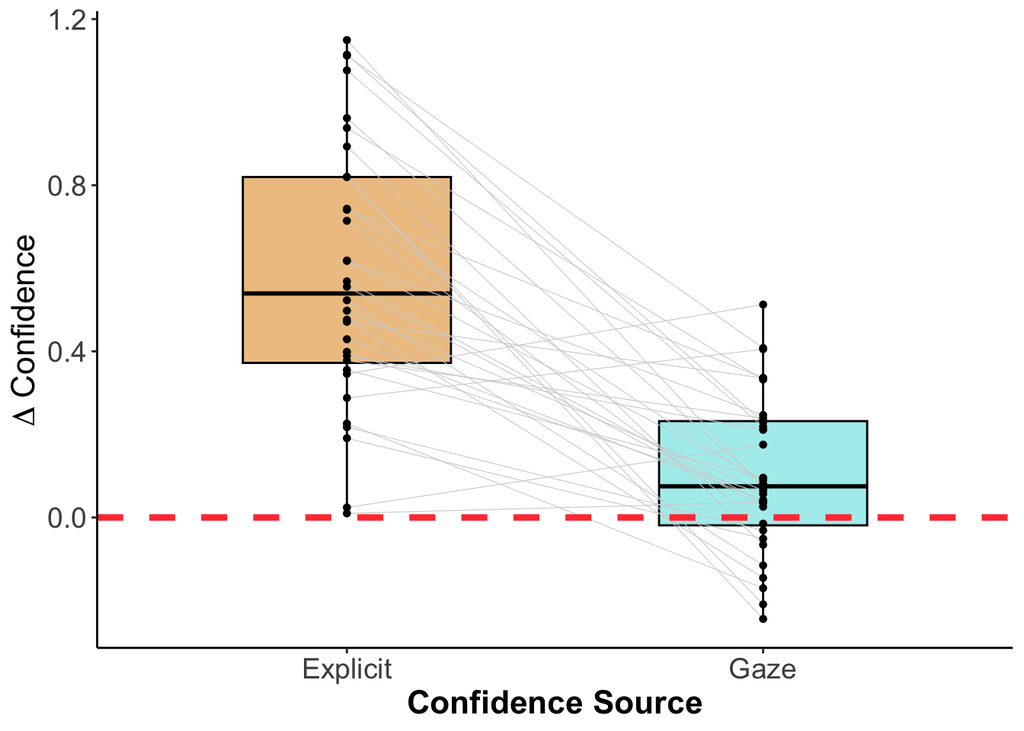

So we see a big win for Explicit Rating! They have much higher metacognition

ttest results of delta confidence expl vs. eye

| estimate | conf.low | conf.high | statistic | p.value | parameter | effsize |
| --- | --- | --- | --- | --- | --- | --- |
| 0.481 | 0.353 | 0.608 | 7.685 | 0 | 31 | 1.358 |

#### stats of each measures metacognitive sensitivity

i.e. delta confidence >0

explicit/eye confidence one sample ttest

| source | mean | lo_ci | hi_ci | statistic | p_val | ES |
| --- | --- | --- | --- | --- | --- | --- |
| expl | 0.583 | 0.469 | 0.697 | 10.437 | 0.000 | 1.845 |
| eye | 0.103 | 0.034 | 0.171 | 3.066 | 0.004 | 0.542 |

### Fig S9: correlation between Explicit and Ocular metacognition

Examine the correlation between Explicit and Ocular metacognitionacross SS

stats of correlation between explicit and ocular metacognition

| r | pval | df | BF |
| --- | --- | --- | --- |
| 0.09 | 0.63 | 31 | 0.43 |

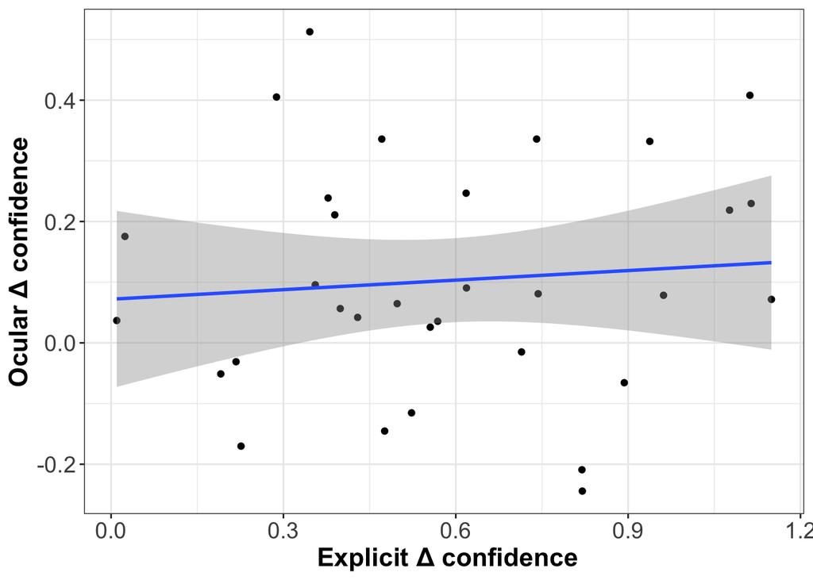

This is interesting! Eye metacognition & Explict Metacognition seem to be somewhat unrelated abilities.

BF is inconclusive

Need to check this with Bayesian null analysis and sample size is still small so prbly think of a way to show at a trial level that the two diverge

##### further test for correlation between metacognition across SS

So let’s try also controling for each Ss’s rule acc

expl. meta by eye meta: rule acc

| term | estimate | std.error | statistic | p.value |
| --- | --- | --- | --- | --- |
| (Intercept) | -0.930 | 0.792 | -1.175 | 0.250 |
| diff_rating_eye | 1.483 | 3.928 | 0.378 | 0.709 |
| m_acc | 2.029 | 1.062 | 1.912 | 0.066 |
| diff_rating_eye:m_acc | -1.808 | 5.117 | -0.353 | 0.727 |

### Fig 4C: serial dependence of explicit and ocular confidence

looking at difference in Serial Dependence in Exp 3 between explicit and ocular confidence rating

Start by simply looking at lag 1 autocorrelation between the two types of confidence

Comparison of Lag1 Autocorrelation of explicit & ocular conf. Exp 3

| group1 | group2 | n1 | n2 | statistic | df | p | effsize |
| --- | --- | --- | --- | --- | --- | --- | --- |
| expl | gz | 32 | 32 | 7.851 | 31 | 0 | 1.388 |

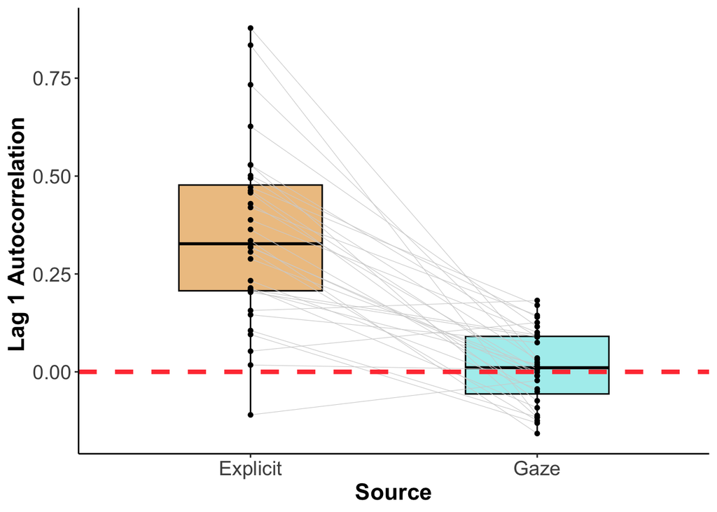

### One-sample ttest of explicit & ocular confidence in exp 3 Is there a significant effect of serial dependence for each type of source Let’s check if each type of confidence’s autocorrealtion of gaze is sig. diff than zero

Summary stats of auto correlation values Exp. 3

| source | mean_auto_corr_val | lo_ci | hi_ci |
| --- | --- | --- | --- |
| expl | 0.351 | 0.268 | 0.433 |
| gz | 0.013 | -0.022 | 0.047 |

one sample t-test of distribution of auto correlation values Exp. 3

| source | .y. | group1 | group2 | n | statistic | df | p | effsize |
| --- | --- | --- | --- | --- | --- | --- | --- | --- |
| expl | auto_corr_val | 1 | null model | 32 | 8.697 | 31 | 0.000 | 1.537 |
| gz | auto_corr_val | 1 | null model | 32 | 0.741 | 31 | 0.464 | 0.131 |

So we see that lag1 autocorr in exp 3 is sig. for explicit but not for ocular

Let’s look at autocorrelation of gaze in exp 1&2 ### One-sample ttest of ocular confidence across experiments 1& 2

Summary stats of ocular auto correlation values Exp. 1&2

| mean_auto_corr_val | lo_ci | hi_ci |
| --- | --- | --- |
| 0.046 | 0.019 | 0.073 |

one sample t-test of distribution of auto correlation values Exp. 1 & 2

| n | statistic | df | p | effsize |
| --- | --- | --- | --- | --- |
| 56 | 3.396 | 55 | 0.001 | 0.454 |

#### SM analysis: test that autocorrelation is not driven by additional factors

Here we are looking at autcorreation but controling for p. choice and prev. trial’s accuracy

Comparison of explicit & ocular confidence contrling for prev acc and p. choice

| .y. | group1 | group2 | n1 | n2 | statistic | df | p | effsize |
| --- | --- | --- | --- | --- | --- | --- | --- | --- |
| auto_corr_val | expl | gz | 32 | 32 | 6.454 | 31 | 0 | 1.141 |